# NYPD Shooting Incident

23/10/2021

## Import Library

```r
  library(tidyverse)
  library(lubridate)
  library(scales)
```

## Import Data

Importing the NYPD Shooting Incident Data form [Catalog Data](https://catalog.data.gov/dataset)

### Import Summary

```r
  summary(nypd_data)
```

```
##   INCIDENT_KEY        OCCUR_DATE         OCCUR_TIME           BORO
##  Min.   :  9953245   Length:23568       Length:23568      Length:23568
##  1st Qu.: 55317014   Class :character   Class1:hms        Class :character
##  Median : 83365370   Mode  :character   Class2:difftime   Mode  :character
##  Mean   :102218616                      Mode  :numeric
##  3rd Qu.:150772442
##  Max.   :222473262
##
##     PRECINCT      JURISDICTION_CODE LOCATION_DESC      STATISTICAL_MURDER_FLAG
##  Min.   :  1.00   Min.   :0.0000    Length:23568       Mode :logical
##  1st Qu.: 44.00   1st Qu.:0.0000    Class :character   FALSE:19080
##  Median : 69.00   Median :0.0000    Mode  :character   TRUE :4488
##  Mean   : 66.21   Mean   :0.3323
##  3rd Qu.: 81.00   3rd Qu.:0.0000
##  Max.   :123.00   Max.   :2.0000
##                   NA's   :2
##  PERP_AGE_GROUP       PERP_SEX          PERP_RACE         VIC_AGE_GROUP
##  Length:23568       Length:23568       Length:23568       Length:23568
##  Class :character   Class :character   Class :character   Class :character
##  Mode  :character   Mode  :character   Mode  :character   Mode  :character
##
##
##
##
##    VIC_SEX            VIC_RACE           X_COORD_CD        Y_COORD_CD
##  Length:23568       Length:23568       Min.   : 914928   Min.   :125757
##  Class :character   Class :character   1st Qu.: 999900   1st Qu.:182565
##  Mode  :character   Mode  :character   Median :1007645   Median :193482
##                                        Mean   :1009363   Mean   :207312
##                                        3rd Qu.:1016807   3rd Qu.:239163
##                                        Max.   :1066815   Max.   :271128
##
##     Latitude       Longitude        Lon_Lat
##  Min.   :40.51   Min.   :-74.25   Length:23568
##  1st Qu.:40.67   1st Qu.:-73.94   Class :character
##  Median :40.70   Median :-73.92   Mode  :character
##  Mean   :40.74   Mean   :-73.91
##  3rd Qu.:40.82   3rd Qu.:-73.88
##  Max.   :40.91   Max.   :-73.70
##
```

## Tidy

Identified the following variables necessary for my analysis on nypd_data.

- PERP_SEX
- VIC_SEX
- BORO
- OCCUR_TIME
- OCCUR_DATE
- Longitude

Tidying the data by removing all other variables, and transforming the OCCUR_DATE from character format to Date Object.

### Tidy Summary

```r
  summary(nypd_data)
```

```
##    OCCUR_DATE          OCCUR_TIME           BORO             PERP_SEX
##  Min.   :2006-01-01   Length:23568      Length:23568       Length:23568
##  1st Qu.:2008-12-30   Class1:hms        Class :character   Class :character
##  Median :2012-02-26   Class2:difftime   Mode  :character   Mode  :character
##  Mean   :2012-10-03   Mode  :numeric
##  3rd Qu.:2016-02-28
##  Max.   :2020-12-31
##    VIC_SEX            Longitude
##  Length:23568       Min.   :-74.25
##  Class :character   1st Qu.:-73.94
##  Mode  :character   Median :-73.92
##                     Mean   :-73.91
##                     3rd Qu.:-73.88
##                     Max.   :-73.70
```

## Missing Data

In the following analysis, the missing data (NA/NR/U) has been ignored.

## Visualization

### Sex based comparison of Perpatrators

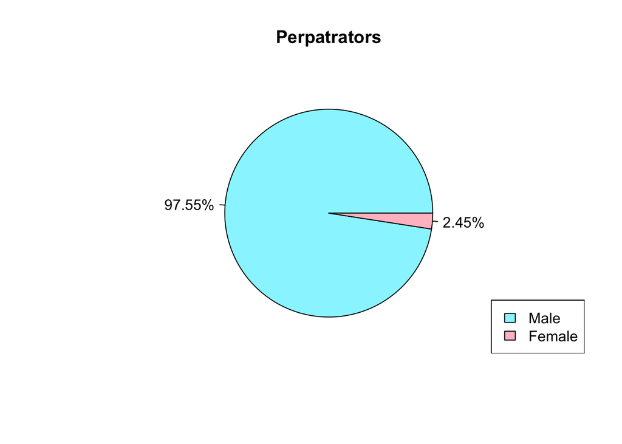

```r
x <- c("Male","Female")
y <- c(nrow(nypd_data %>% filter(PERP_SEX == 'M')),
       nrow(nypd_data %>% filter(PERP_SEX == 'F')))
perc <- paste0(round(100 * y/sum(y), 2), "%")
colors <- c('cadetblue1','pink')
pie(y,label = perc,main = "Perpatrators", col = colors)
legend("bottomright", x, fill = colors)
```

### Sex based comparison of Victims

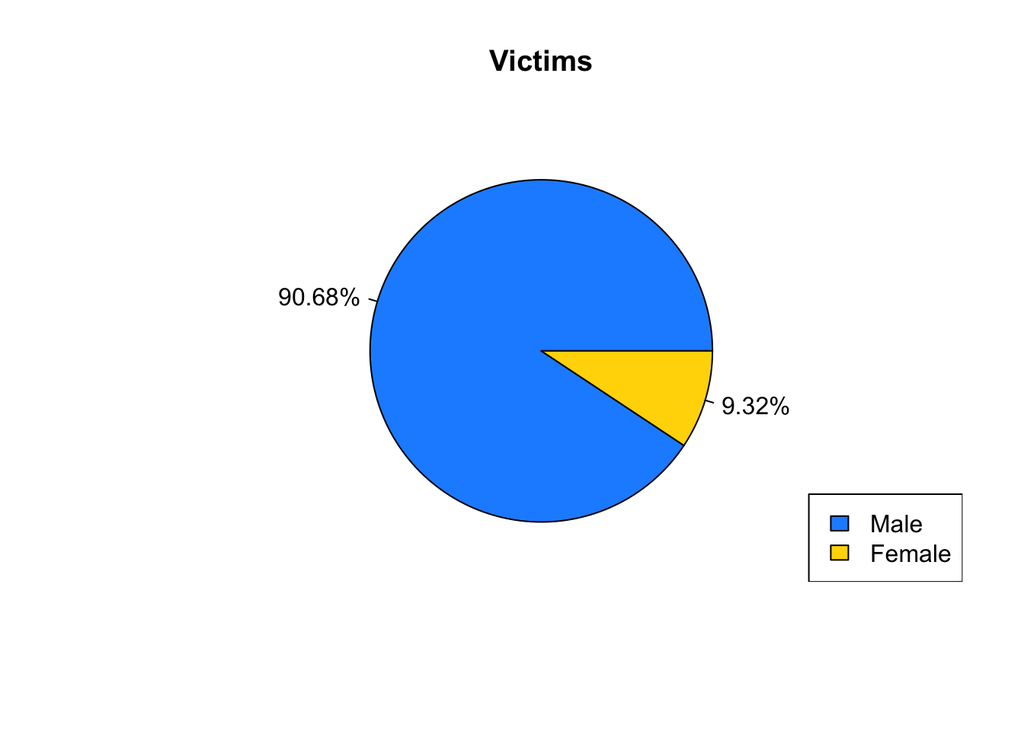

```r
x <- c("Male","Female")
y <- c(nrow(nypd_data %>% filter(VIC_SEX == 'M')),
       nrow(nypd_data %>% filter(VIC_SEX == 'F')))
perc <- paste0(round(100 * y/sum(y), 2), "%")
colors <- c('dodgerblue1','gold')
pie(y,label = perc,main = "Victims", col = colors)
legend("bottomright", x, fill = colors)
```

### Sex based Victims ratio of Male Perpatrators

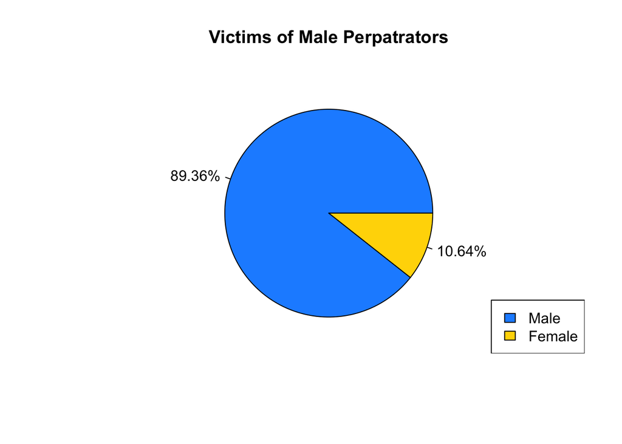

```r
pmd <- nypd_data %>% filter(PERP_SEX == 'M')
pmd_f_c <- nrow(pmd %>% filter(VIC_SEX == "F"))
pmd_m_c <- nrow(pmd %>% filter(VIC_SEX == "M"))
x <- c("Male","Female")
y <- c(pmd_m_c,pmd_f_c)
perc <- paste0(round(100 * y/sum(y), 2), "%")
colors <- c('dodgerblue1','gold')
pie(y,label = perc,main = "Victims of Male Perpatrators", col = colors)
legend("bottomright", x, fill = colors)
```

### Sex based Victims ratio of Female Perpatrators

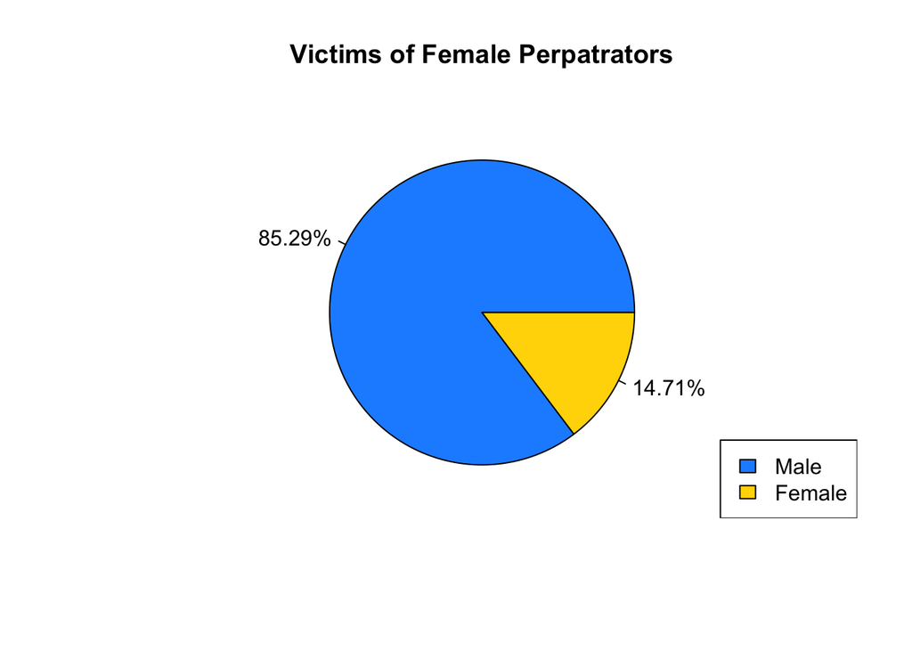

```r
pmd <- nypd_data %>% filter(PERP_SEX == 'F')
pfd_f_c <- nrow(pmd %>% filter(VIC_SEX == "F"))
pfd_m_c <- nrow(pmd %>% filter(VIC_SEX == "M"))
x <- c("Male","Female")
y <- c(pfd_m_c,pfd_f_c)
perc <- paste0(round(100 * y/sum(y), 2), "%")
colors <- c('dodgerblue1','gold')
pie(y,label = perc,main = "Victims of Female Perpatrators", col = colors)
legend("bottomright", x, fill = colors)
```

### Sex based Perpatrators ratio of Male Victims

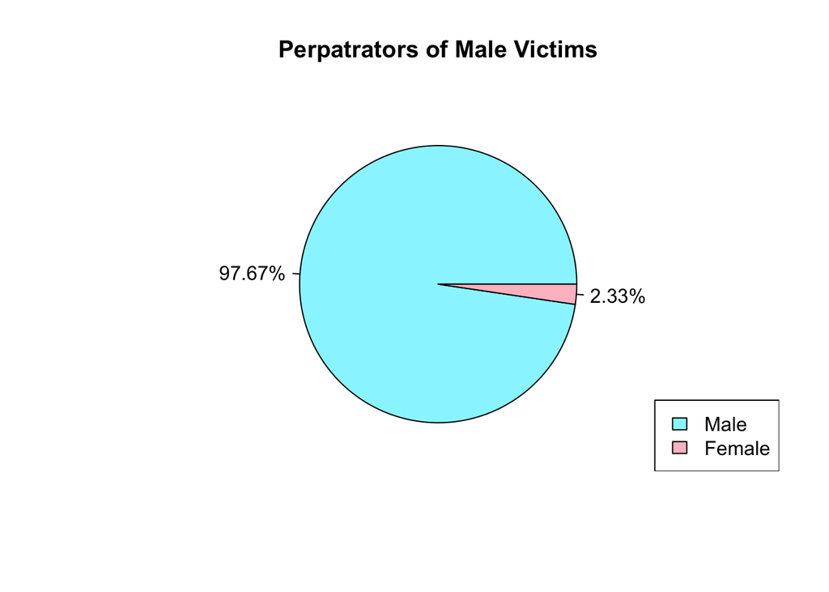

```r
pmd <- nypd_data %>% filter(VIC_SEX == 'M')
pfd_f_c <- nrow(pmd %>% filter(PERP_SEX == "F"))
pfd_m_c <- nrow(pmd %>% filter(PERP_SEX == "M"))
x <- c("Male","Female")
y <- c(pfd_m_c,pfd_f_c)
perc <- paste0(round(100 * y/sum(y), 2), "%")
colors <- c('cadetblue1','pink')
pie(y,label = perc,main = "Perpatrators of Male Victims", col = colors)
legend("bottomright", x, fill = colors)
```

### Sex based Perpatrators ratio of Female Victims

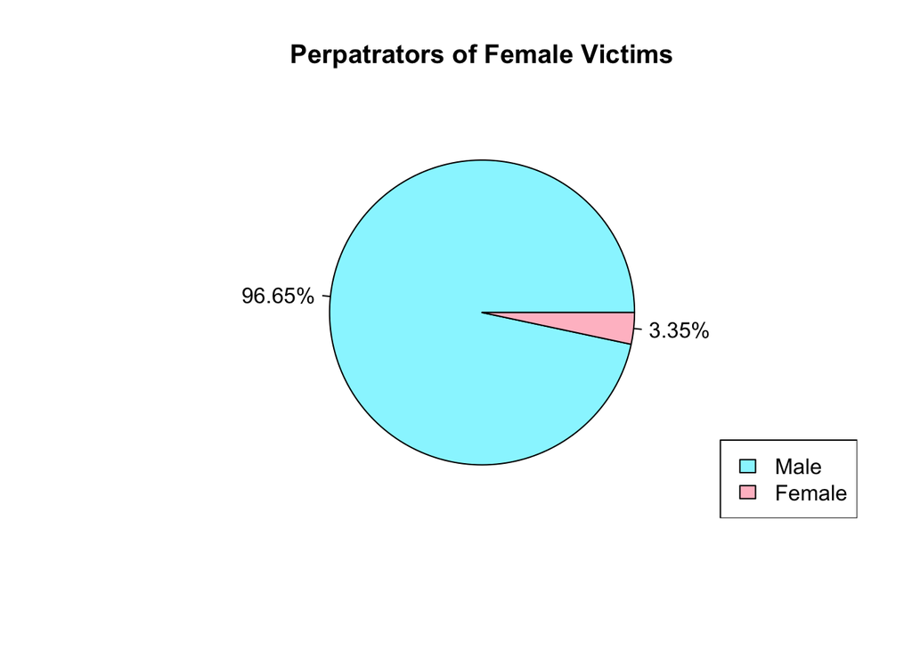

```r
pmd <- nypd_data %>% filter(VIC_SEX == 'F')
pfd_f_c <- nrow(pmd %>% filter(PERP_SEX == "F"))
pfd_m_c <- nrow(pmd %>% filter(PERP_SEX == "M"))
x <- c("Male","Female")
y <- c(pfd_m_c,pfd_f_c)
perc <- paste0(round(100 * y/sum(y), 2), "%")
colors <- c('cadetblue1','pink')
pie(y,label = perc,main = "Perpatrators of Female Victims", col = colors)
legend("bottomright", x, fill = colors)
```

### Date-Time Scatter plot

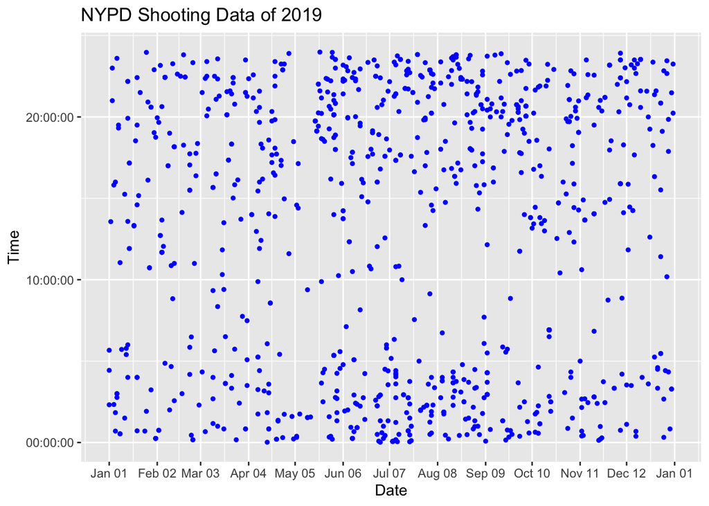

```r
  tt_data <- nypd_data %>% filter(OCCUR_DATE > '2018-12-31' & OCCUR_DATE < '2020-1-1')
  tp <- ggplot(tt_data, aes(OCCUR_DATE, OCCUR_TIME)) +
           geom_point(na.rm=TRUE, color="blue", size=1) +
           ggtitle("NYPD Shooting Data of 2019") +
           xlab("Date") + ylab("Time")
  tpb <- tp + (scale_x_date(breaks = date_breaks("1 month"),labels=date_format("%b %m")))
  tt_data1 <- nypd_data %>% filter(OCCUR_DATE > '2019-12-31' & OCCUR_DATE < '2020-12-6')
  tp1 <- ggplot(tt_data1, aes(OCCUR_DATE, OCCUR_TIME)) +
           geom_point(na.rm=TRUE, color="blue", size=1) +
           ggtitle("NYPD Shooting Data of 2020") +
           xlab("Date") + ylab("Time")
  tpb1 <- tp1 + (scale_x_date(breaks = date_breaks("1 month"),labels=date_format("%b %m")))

  tpb
```

```r
  tpb1
```

[figure not shown]

## Analysis of Date-Time Scatter Plot

The Shooting Incidents drop in the mid-morining(8 to 11 am). Shooting Incidents have increased in 2020.

### Borough wise Density Comparison

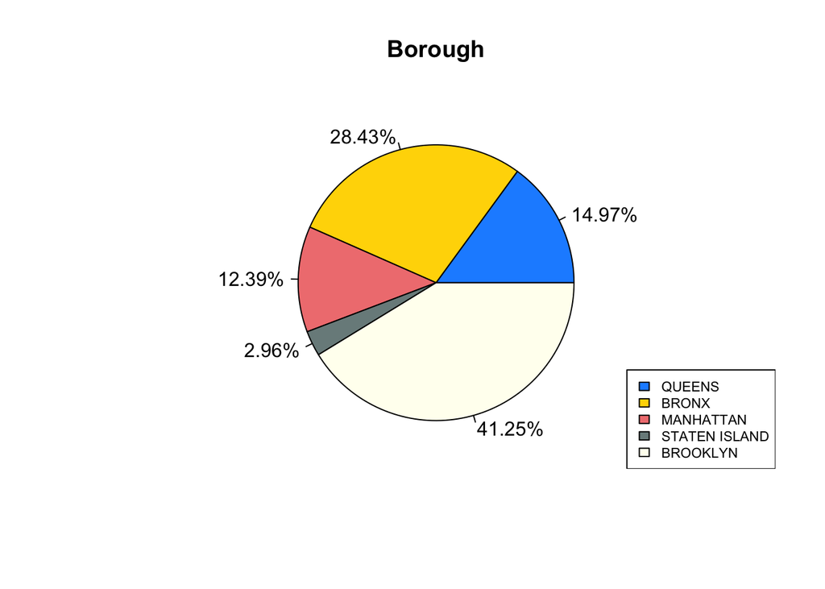

```r
b_l <- unique(nypd_data$BORO)
y <- c(nrow(nypd_data %>% filter(BORO == b_l[1])),
       nrow(nypd_data %>% filter(BORO == b_l[2])),
       nrow(nypd_data %>% filter(BORO == b_l[3])),
       nrow(nypd_data %>% filter(BORO == b_l[4])),
       nrow(nypd_data %>% filter(BORO == b_l[5])))
perc <- paste0(round(100 * y/sum(y), 2), "%")
colors <- c('dodgerblue1','gold','lightcoral','lightcyan4','ivory1')
pie(y,label = perc,main = "Borough", col = colors)
legend("bottomright", b_l, fill = colors, cex = 0.7)
```

### Saftey Index of Boroughs

The index is in highest to lowest order.

1. Staten Island
2. Manhattan
3. Queens
4. Bronx
5. Brooklyn

### Model

A basic **Linear Model**, which predicts the **Longitude** of a crime on a specific date. This model uses the existing data to predict the outcome, which has been compared with the real outcomes.

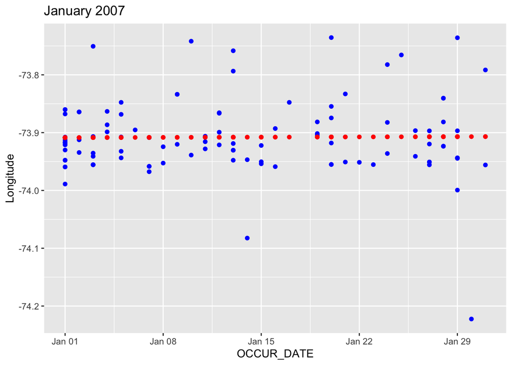

```r
m_data <- nypd_data %>% filter(OCCUR_DATE >= "2007-1-1" & OCCUR_DATE <= "2007-1-31")
mod <- lm(Longitude ~ OCCUR_DATE,data = m_data)
m_data_pred <- m_data %>% mutate(pred = predict(mod))
m_data_pred %>% ggplot() +
 ggtitle("January 2007") +
 geom_point(aes(x = OCCUR_DATE,y = Longitude),color = "blue") +
 geom_point(aes(x = OCCUR_DATE,y = pred),color = "red")
```

## Conclusion

In this report the analyses, model and visualizations were on, how the Ratio of each provided Gender compared to each other in Perpetrators and Victims, and saw the period in which these incidents happen, and a Linear Model. For future work, many other analyses are possible, such as a **Demographics-based Visualization** or an **Age-Group-based Visualization**, etc.